# Tourist flats in Barcelona

author: Jagoda

September 2018

## A little bit of background

This project was done as an assignement from the course “Introduction to R for journalists” led by Andrew Ba Tran, data reporter on The Washington Post’s rapid response investigative team. You can check it out [here](http://learn.r-journalism.com/en/)!

Since I moved recently to Barcelona I decided to explore a bit about information about the city : ) and as fun of an open data, I had to check out [the open data portal run by the town hall of Barcelona](http://opendata-ajuntament.barcelona.cat/es/). There I found dataset on flats used for tourist accomodation. It’s interesting topic as recently local authorities started to regulate the rental of flats for tourists, including services as Airbnb. In dataset, each row equals to one location, with attributes of : district, street, house number, flat number, longitud and latitude.

I thought it would be interesting to see in *which parts of the city are the most of flats rented for tourists*, and *what is its ratio to local flats*.

## Analysis step

**Data source**: datasets from [the open data portal run by the town hall of Barcelona](http://opendata-ajuntament.barcelona.cat/es/):

- [Tourist housing in the city of Barcelona](http://opendata-ajuntament.barcelona.cat/data/en/dataset/habitatges-us-turistic)
- [“Population by neighbourhoof, nationality and genre of the city of Barcelona](http://opendata-ajuntament.barcelona.cat/data/en/dataset/est-padro-nacionalitat-sexe)
- [Shapefile with district boundaries](https://lolivas.carto.com/tables/bcn_districte_ed50_shp/public)
1. **Importing files**. Troubleshoot encoding of catalan symbols.
2. **Wrangling data and joining tables.** Dataset were fairly tidy, but not perfect:
- For tourist housing, as each row equal to location of flat, I calculated nr of flats per district, cleaned district names and added column with district codes to be able to join it with other datasets.
- Population data comes with each row equal to *barrio* (sub-district) level data, thus I used it to compute estimated number of local housing in following steps:
1. calculated population per district,
2. calculated estimated number of flats per district using standard HH size (source included in code),
3. joined two datasets into ne table and calculated number of tourist flat per 100 local flats (ratio).

Finally, in so far created dataset I had to transform column with district code from number to character, fix the format so it doesn’t start with zero and subsequently turn it into factor so it would match the format of district code’s column from shapefile in order to join them while creating map.

3. **Visualisation.** I decided to share two graphs. First is a bar graph showing tourist housing per district, which was first one I made and which made me question ratio of tourist housing to population/local housing. It’s very simple but I took it as opportunity to play with layout. Second visualisation is the scatterplot comparing tourist housing vs local housing, including ratio of tourist flats per 100 local flats as size factor. No fireworks, but should be also neat. I think this data is actually shown better by the map, which is the final visualisation.

#### **Outcomes:** Depending on Barcelona’s district, you can find from 0.03 to 4.19 tourist flats for every 100 local flats. That’s quite a few, isn’t it? Take a look on map to see where to stay to be out of the beaten track!

### Wrangling data

Calculating nr of tourist flats per district plus a bit of cleaning

```r
library(readr)
library(dplyr)
library(ggplot2)
library(forcats)
library(stringr)
library(ggrepel)
library(sf)
library(tidyverse)

#importing files

#housing
viviendas <- read.csv("http://opendata-ajuntament.barcelona.cat/data/dataset/c748799e-1079-44b1-9e60-88d936a3fe70/resource/a5a6cae9-a5d7-47e9-ab39-15b600210a0b/download", fileEncoding = "UTF-8")
population <-  read.csv("http://opendata-ajuntament.barcelona.cat/data/dataset/3a0934e4-cdba-4056-950a-331429cb8908/resource/da151a88-9dbe-4715-9ebd-9982506deb85/download/2018_padro_nacionalitat_per_sexe.csv", fileEncoding = "UTF-8")
#population
pop <- select(population, code=Codi_Districte,district=Nom_Districte,gender=Sexe,nacionality=Nacionalitat,Ppl=Nombre)
#shapefile
bcn_shp <- "bcn_district/bcn_districte_ed50_shp.shp"
bcn_geo <- st_read(bcn_shp)

#organising housing data
barrio <- viviendas %>%
          group_by(N_EXPEDIENT) %>%
          summarise(flats=n()) %>%
          arrange(desc(flats)) %>%
          rename(district=N_EXPEDIENT)
barrio$district <- as.character(barrio$district)
barrio$district <- str_to_title(barrio$district)
barrio$district <- str_replace(barrio$district, "L'e","E")

#calculating poplation per district
pop_dist <- pop %>%
  group_by(district, code) %>%
  summarise(pop=sum(Ppl))

#adding district codes to table with housing data in order to have unique ID
barrio2 <- mutate(barrio,
  code=as.numeric(case_when(
    district=="Ciutat Vella"~"1",
    district=="Eixample"~"2",
    district=="Sants-Montjuïc"~"3",
    district=="Les Corts"~"4",
    district=="Sarria-Sant Gervasi"~"5",
    district=="Gracia"~"6",
    district=="Horta-Guinardó"~"7",
    district=="Nou Barris"~"8",
    district=="Sant Andreu"~"9",
    district=="Sant Marti"~"10")))

#joining two tables
table <- left_join(pop_dist,barrio2,by="code")
table <- select(table,district=district.x, code, pop,flats)

#calculating average HH size in cataluna=2.49 Source: http://www.ine.es/en/prensa/ech_2017_en.pdf
table2 <- table %>%
  mutate(loc_flats=round((pop/2.49),digits=0)) %>%
  mutate(ratioPer100=round((flats*100)/loc_flats,digits=2))
table <- arrange(table, desc(pop))

#fixing codes in data table to factor in same level as shapefile
table2$code<-as.character(table2$code)
table2$code<- str_c("0",table2$code)
table2$code<- str_replace(table2$code,"010","10")
table2$code<-as.factor(table2$code)
```

## Creating graphs

#### Number of flats per district

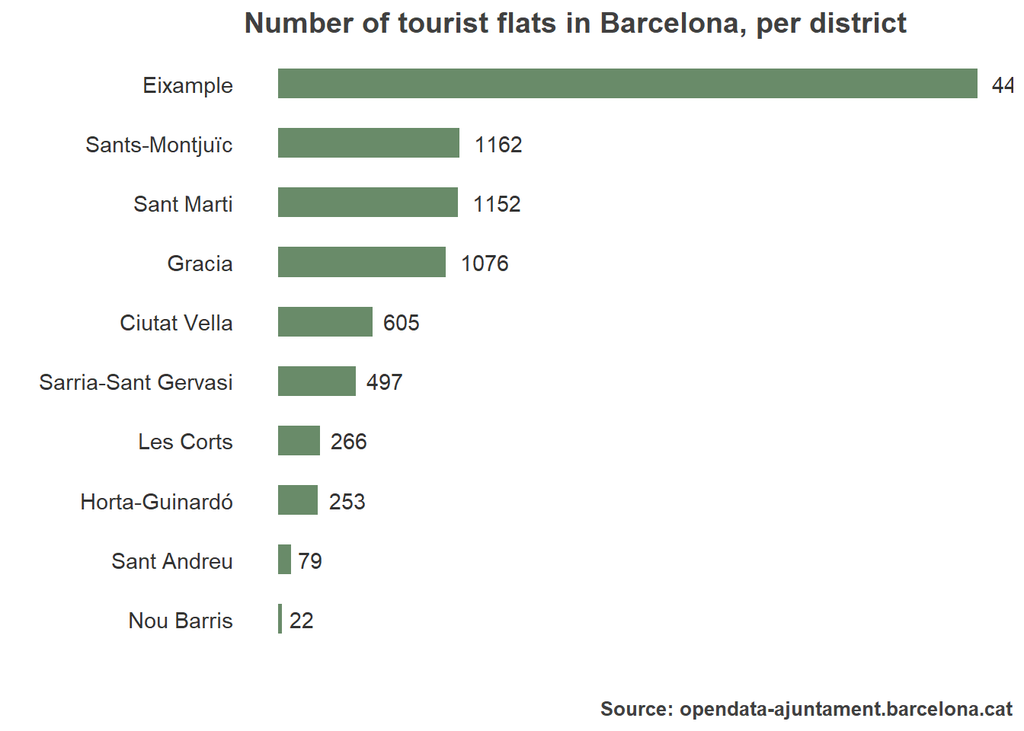

```r
ggplot(barrio,
       aes(x=fct_reorder(district, flats, desc=TRUE), y=flats))+
  geom_bar(stat="identity", fill="darkseagreen4", width = 0.5 )+
  coord_flip()+
  geom_text(aes(label=flats), color="grey20", hjust=-0.3)+
  labs(x="", y="",
       title = "Number of tourist flats in Barcelona, per district",
       caption = "Source: opendata-ajuntament.barcelona.cat") +
  theme_minimal()+
  theme(panel.border = element_blank(),
        panel.grid.major = element_blank(),
        panel.grid.minor = element_blank(),
        axis.line = element_blank(),
        axis.text.x = element_blank(),
        axis.text=element_text(size=11, color = "grey20"),
        title=element_text(color="grey25",size=12,face="bold"))
```

#### Number of tourist housing VS local flats, per district

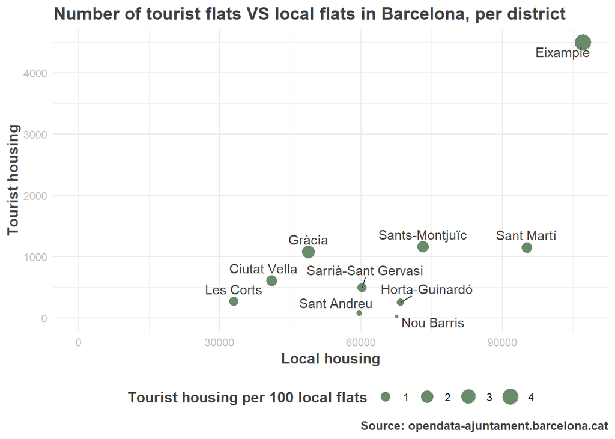

```r
ggplot(table2,
       aes(x=loc_flats, y=flats))+
  geom_point(aes(size=ratioPer100),color="darkseagreen4")+
  expand_limits(x = 0, y = 0) +
  geom_text_repel(aes(label=district), color="grey 25", vjust=-0.75)+
  labs(x="Local housing", y="Tourist housing",
       size="Tourist housing per 100 local flats",
       title = "Number of tourist flats VS local flats in Barcelona, per district",
       caption = "Source: opendata-ajuntament.barcelona.cat") +
  theme_minimal()+
  theme(legend.position = "bottom",
        axis.text=element_text(size=9, color="grey"),
        title=element_text(color="grey25",size=12,face="bold"))
```

## Final soultion: map

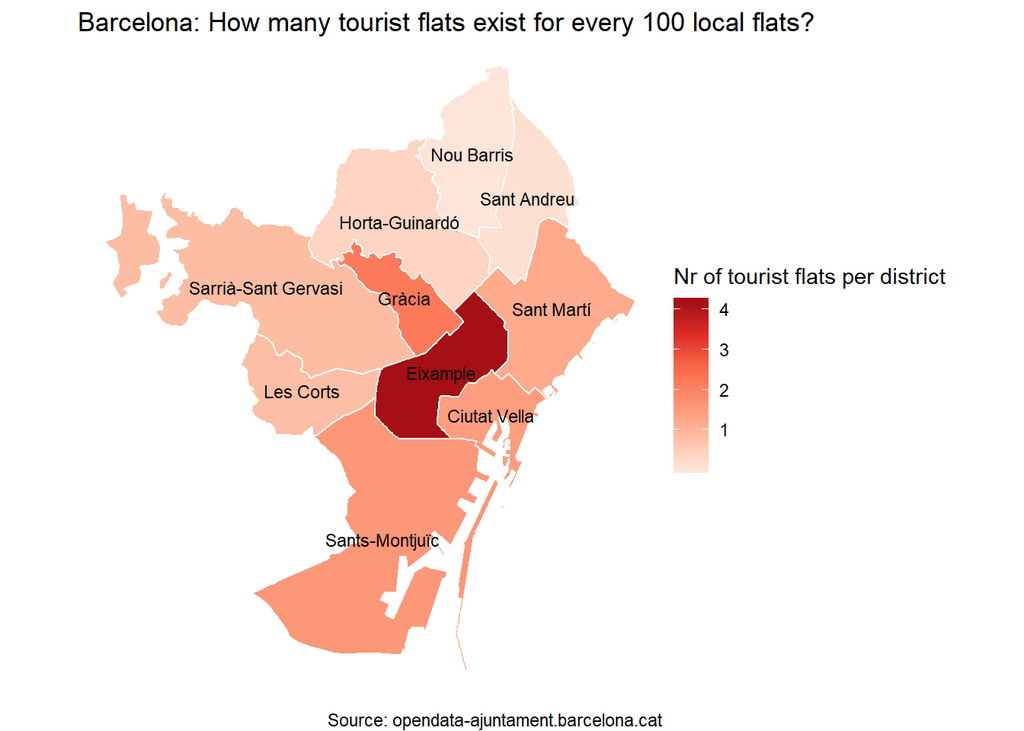

```r
dist_data <- left_join(bcn_geo, table2,
                          by=c("c_distri"="code"))

dist_data2 <- mutate(dist_data,
  lon = map_dbl(geometry, ~st_centroid(.x)[[1]]),
  lat = map_dbl(geometry, ~st_centroid(.x)[[2]]))

ggplot(dist_data2) +
  geom_sf(aes(fill=ratioPer100), color="white")+
    scale_fill_distiller(palette="Reds", direction=1, name="Nr of tourist flats per district") +
  geom_text(aes(label = district, x = lon, y = lat), size = 3)+
  labs(title="Barcelona: How many tourist flats exist for every 100 local flats?", caption="Source: opendata-ajuntament.barcelona.cat")+
  theme_void()+
  theme(panel.grid.major = element_line(colour = 'transparent'))
```